# Risk Factor Analysis

## Outcome Variable

**Outcome Variable:** ever_stunted

## Predictor Variables

**Intervention Variable:** predfeed3

**Adjustment Set:**

- arm
- month
- brthmon
- W_mage
- meducyrs
- feducyrs
- hhwealth_quart
- hfoodsec
- W_mhtcm
- W_mwtkg
- W_mbmi
- vagbrth
- W_gagebrth
- W_birthwt
- W_birthlen
- W_nrooms
- W_nchldlt5
- W_parity
- impfloor
- impsan
- safeh20
- delta_W_mage
- delta_meducyrs
- delta_feducyrs
- delta_hhwealth_quart
- delta_hfoodsec
- delta_W_mhtcm
- delta_W_mwtkg
- delta_W_mbmi
- delta_vagbrth
- delta_W_gagebrth
- delta_W_birthwt
- delta_W_birthlen
- delta_W_nrooms
- delta_W_nchldlt5
- delta_W_parity
- delta_impfloor
- delta_impsan
- delta_safeh20

## Stratifying Variables

The analysis was stratified on these variable(s):

- agecat
- studyid
- country

## Data Summary

| agecat | studyid | country | predfeed3 | ever_stunted | n_cell | n |
| --- | --- | --- | --- | --- | --- | --- |
| 0-24 months (no birth st.) | EE | PAKISTAN | 1 | 0 | 4 | 21 |
| 0-24 months (no birth st.) | EE | PAKISTAN | 1 | 1 | 17 | 21 |
| 0-24 months (no birth st.) | EE | PAKISTAN | 0 | 0 | 0 | 21 |
| 0-24 months (no birth st.) | EE | PAKISTAN | 0 | 1 | 0 | 21 |
| 0-24 months (no birth st.) | GMS-Nepal | NEPAL | 1 | 0 | 116 | 380 |
| 0-24 months (no birth st.) | GMS-Nepal | NEPAL | 1 | 1 | 201 | 380 |
| 0-24 months (no birth st.) | GMS-Nepal | NEPAL | 0 | 0 | 22 | 380 |
| 0-24 months (no birth st.) | GMS-Nepal | NEPAL | 0 | 1 | 41 | 380 |
| 0-24 months (no birth st.) | JiVitA-3 | BANGLADESH | 1 | 0 | 6792 | 10148 |
| 0-24 months (no birth st.) | JiVitA-3 | BANGLADESH | 1 | 1 | 2425 | 10148 |
| 0-24 months (no birth st.) | JiVitA-3 | BANGLADESH | 0 | 0 | 689 | 10148 |
| 0-24 months (no birth st.) | JiVitA-3 | BANGLADESH | 0 | 1 | 242 | 10148 |
| 0-24 months (no birth st.) | JiVitA-4 | BANGLADESH | 1 | 0 | 63 | 113 |
| 0-24 months (no birth st.) | JiVitA-4 | BANGLADESH | 1 | 1 | 40 | 113 |
| 0-24 months (no birth st.) | JiVitA-4 | BANGLADESH | 0 | 0 | 4 | 113 |
| 0-24 months (no birth st.) | JiVitA-4 | BANGLADESH | 0 | 1 | 6 | 113 |
| 0-24 months (no birth st.) | MAL-ED | BANGLADESH | 1 | 0 | 78 | 202 |
| 0-24 months (no birth st.) | MAL-ED | BANGLADESH | 1 | 1 | 86 | 202 |
| 0-24 months (no birth st.) | MAL-ED | BANGLADESH | 0 | 0 | 16 | 202 |
| 0-24 months (no birth st.) | MAL-ED | BANGLADESH | 0 | 1 | 22 | 202 |
| 0-24 months (no birth st.) | MAL-ED | BRAZIL | 1 | 0 | 69 | 175 |
| 0-24 months (no birth st.) | MAL-ED | BRAZIL | 1 | 1 | 17 | 175 |
| 0-24 months (no birth st.) | MAL-ED | BRAZIL | 0 | 0 | 75 | 175 |
| 0-24 months (no birth st.) | MAL-ED | BRAZIL | 0 | 1 | 14 | 175 |
| 0-24 months (no birth st.) | MAL-ED | INDIA | 1 | 0 | 48 | 184 |
| 0-24 months (no birth st.) | MAL-ED | INDIA | 1 | 1 | 79 | 184 |
| 0-24 months (no birth st.) | MAL-ED | INDIA | 0 | 0 | 35 | 184 |
| 0-24 months (no birth st.) | MAL-ED | INDIA | 0 | 1 | 22 | 184 |
| 0-24 months (no birth st.) | MAL-ED | NEPAL | 1 | 0 | 77 | 201 |
| 0-24 months (no birth st.) | MAL-ED | NEPAL | 1 | 1 | 28 | 201 |

[output cut: 102 more lines]

The following strata were considered:

- agecat: 0-24 months (no birth st.), studyid: EE, country: PAKISTAN
- agecat: 0-24 months (no birth st.), studyid: GMS-Nepal, country: NEPAL
- agecat: 0-24 months (no birth st.), studyid: JiVitA-3, country: BANGLADESH
- agecat: 0-24 months (no birth st.), studyid: JiVitA-4, country: BANGLADESH
- agecat: 0-24 months (no birth st.), studyid: MAL-ED, country: BANGLADESH
- agecat: 0-24 months (no birth st.), studyid: MAL-ED, country: BRAZIL
- agecat: 0-24 months (no birth st.), studyid: MAL-ED, country: INDIA
- agecat: 0-24 months (no birth st.), studyid: MAL-ED, country: NEPAL
- agecat: 0-24 months (no birth st.), studyid: MAL-ED, country: PERU
- agecat: 0-24 months (no birth st.), studyid: MAL-ED, country: SOUTH AFRICA
- agecat: 0-24 months (no birth st.), studyid: MAL-ED, country: TANZANIA, UNITED REPUBLIC OF
- agecat: 0-6 months (no birth st.), studyid: EE, country: PAKISTAN
- agecat: 0-6 months (no birth st.), studyid: GMS-Nepal, country: NEPAL
- agecat: 0-6 months (no birth st.), studyid: JiVitA-3, country: BANGLADESH
- agecat: 0-6 months (no birth st.), studyid: JiVitA-4, country: BANGLADESH
- agecat: 0-6 months (no birth st.), studyid: MAL-ED, country: BANGLADESH
- agecat: 0-6 months (no birth st.), studyid: MAL-ED, country: BRAZIL
- agecat: 0-6 months (no birth st.), studyid: MAL-ED, country: INDIA
- agecat: 0-6 months (no birth st.), studyid: MAL-ED, country: NEPAL
- agecat: 0-6 months (no birth st.), studyid: MAL-ED, country: PERU
- agecat: 0-6 months (no birth st.), studyid: MAL-ED, country: SOUTH AFRICA
- agecat: 0-6 months (no birth st.), studyid: MAL-ED, country: TANZANIA, UNITED REPUBLIC OF
- agecat: 6-24 months, studyid: EE, country: PAKISTAN
- agecat: 6-24 months, studyid: GMS-Nepal, country: NEPAL
- agecat: 6-24 months, studyid: JiVitA-3, country: BANGLADESH
- agecat: 6-24 months, studyid: JiVitA-4, country: BANGLADESH
- agecat: 6-24 months, studyid: MAL-ED, country: BANGLADESH
- agecat: 6-24 months, studyid: MAL-ED, country: BRAZIL
- agecat: 6-24 months, studyid: MAL-ED, country: INDIA
- agecat: 6-24 months, studyid: MAL-ED, country: NEPAL
- agecat: 6-24 months, studyid: MAL-ED, country: PERU
- agecat: 6-24 months, studyid: MAL-ED, country: SOUTH AFRICA
- agecat: 6-24 months, studyid: MAL-ED, country: TANZANIA, UNITED REPUBLIC OF

### Dropped Strata

Some strata were dropped due to rare outcomes:

- agecat: 0-24 months (no birth st.), studyid: EE, country: PAKISTAN
- agecat: 0-24 months (no birth st.), studyid: JiVitA-4, country: BANGLADESH
- agecat: 0-6 months (no birth st.), studyid: EE, country: PAKISTAN
- agecat: 0-6 months (no birth st.), studyid: JiVitA-4, country: BANGLADESH
- agecat: 0-6 months (no birth st.), studyid: MAL-ED, country: NEPAL
- agecat: 6-24 months, studyid: EE, country: PAKISTAN
- agecat: 6-24 months, studyid: JiVitA-4, country: BANGLADESH

## Methods Detail

We’re interested in the causal parameters $E[Y_a]$ for all values of $a \in \mathcal{A}$. These parameters represent the mean outcome if, possibly contrary to fact, we intervened to set all units to have $A=a$. Under the randomization and positivity assumptions, these are identified by the statistical parameters $\psi_a=E_W[E_{Y|A,W}(Y|A=a,W)]$. In addition, we’re interested in the mean of $Y$, $E[Y]$ under no intervention (the observed mean). We will estimate these parameters by using SuperLearner to fit the relevant likelihood factors – $E_{Y|A,W}(Y|A=a,W)$ and $p(A=a|W)$, and then updating our likelihood fit using a joint TMLE.

For unadjusted analyses ($W=\{\}$), initial likelihoods were estimated using Lrnr_glm to estimate the simple $E(Y|A)$ and Lrnr_mean to estimate $p(A)$. For adjusted analyses, a small library containing Lrnr_glmnet, Lrnr_xgboost, and Lrnr_mean was used.

Having estimated these parameters, we will then use the delta method to estimate relative risks and attributable risks relative to a prespecified baseline level of $A$.

# Results Detail

## Results Plots

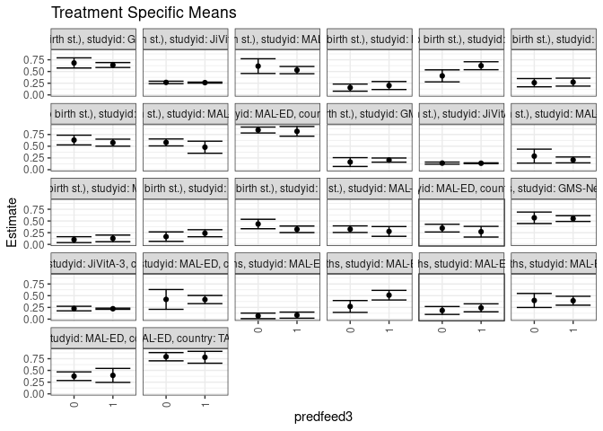

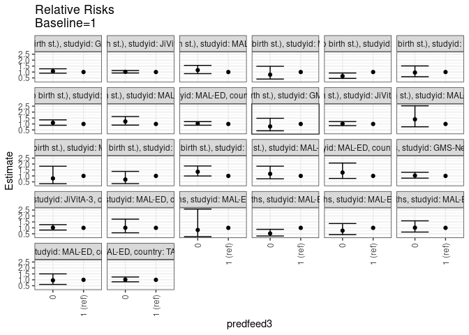

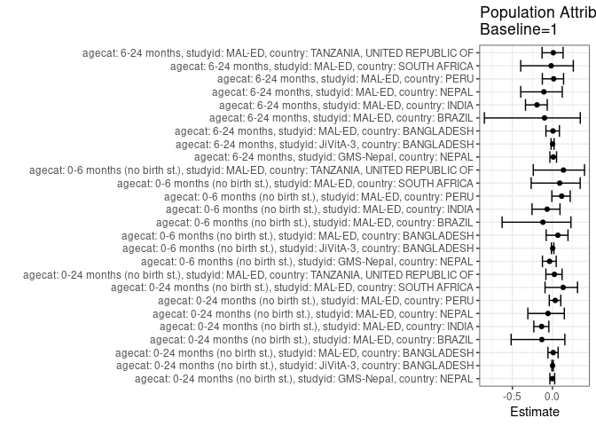

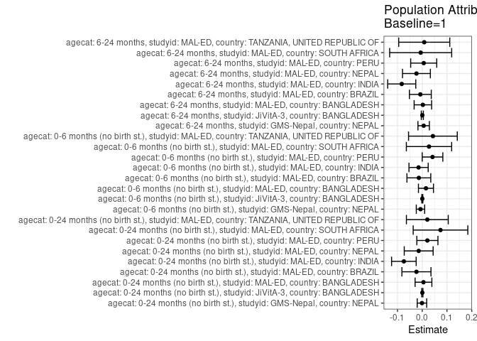

## Results Table

### Parameter: TSM

| agecat | studyid | country | intervention_level | baseline_level | estimate | ci_lower | ci_upper |
| --- | --- | --- | --- | --- | --- | --- | --- |
| 0-24 months (no birth st.) | GMS-Nepal | NEPAL | 1 | NA | 0.6379397 | 0.5852136 | 0.6906657 |
| 0-24 months (no birth st.) | GMS-Nepal | NEPAL | 0 | NA | 0.6823458 | 0.5741657 | 0.7905260 |
| 0-24 months (no birth st.) | JiVitA-3 | BANGLADESH | 1 | NA | 0.2624088 | 0.2516214 | 0.2731961 |
| 0-24 months (no birth st.) | JiVitA-3 | BANGLADESH | 0 | NA | 0.2666177 | 0.2405044 | 0.2927310 |
| 0-24 months (no birth st.) | MAL-ED | BANGLADESH | 1 | NA | 0.5295779 | 0.4526299 | 0.6065258 |
| 0-24 months (no birth st.) | MAL-ED | BANGLADESH | 0 | NA | 0.6145279 | 0.4574125 | 0.7716432 |
| 0-24 months (no birth st.) | MAL-ED | BRAZIL | 1 | NA | 0.2005148 | 0.1154647 | 0.2855648 |
| 0-24 months (no birth st.) | MAL-ED | BRAZIL | 0 | NA | 0.1560054 | 0.0802858 | 0.2317250 |
| 0-24 months (no birth st.) | MAL-ED | INDIA | 1 | NA | 0.6230131 | 0.5381683 | 0.7078580 |
| 0-24 months (no birth st.) | MAL-ED | INDIA | 0 | NA | 0.4066665 | 0.2785726 | 0.5347604 |
| 0-24 months (no birth st.) | MAL-ED | NEPAL | 1 | NA | 0.2729718 | 0.1880981 | 0.3578455 |
| 0-24 months (no birth st.) | MAL-ED | NEPAL | 0 | NA | 0.2610232 | 0.1734495 | 0.3485969 |
| 0-24 months (no birth st.) | MAL-ED | PERU | 1 | NA | 0.5760179 | 0.5013252 | 0.6507107 |
| 0-24 months (no birth st.) | MAL-ED | PERU | 0 | NA | 0.6312991 | 0.5276508 | 0.7349474 |
| 0-24 months (no birth st.) | MAL-ED | SOUTH AFRICA | 1 | NA | 0.4789120 | 0.3498824 | 0.6079415 |
| 0-24 months (no birth st.) | MAL-ED | SOUTH AFRICA | 0 | NA | 0.5807190 | 0.5067100 | 0.6547281 |
| 0-24 months (no birth st.) | MAL-ED | TANZANIA, UNITED REPUBLIC OF | 1 | NA | 0.8172151 | 0.7141628 | 0.9202673 |
| 0-24 months (no birth st.) | MAL-ED | TANZANIA, UNITED REPUBLIC OF | 0 | NA | 0.8459934 | 0.7829155 | 0.9090714 |
| 0-6 months (no birth st.) | GMS-Nepal | NEPAL | 1 | NA | 0.2044251 | 0.1599535 | 0.2488967 |
| 0-6 months (no birth st.) | GMS-Nepal | NEPAL | 0 | NA | 0.1621136 | 0.0677037 | 0.2565235 |
| 0-6 months (no birth st.) | JiVitA-3 | BANGLADESH | 1 | NA | 0.1369700 | 0.1290276 | 0.1449124 |
| 0-6 months (no birth st.) | JiVitA-3 | BANGLADESH | 0 | NA | 0.1394537 | 0.1174405 | 0.1614669 |
| 0-6 months (no birth st.) | MAL-ED | BANGLADESH | 1 | NA | 0.2077164 | 0.1453884 | 0.2700443 |
| 0-6 months (no birth st.) | MAL-ED | BANGLADESH | 0 | NA | 0.2887073 | 0.1398552 | 0.4375594 |
| 0-6 months (no birth st.) | MAL-ED | BRAZIL | 1 | NA | 0.1279070 | 0.0571170 | 0.1986970 |
| 0-6 months (no birth st.) | MAL-ED | BRAZIL | 0 | NA | 0.1011236 | 0.0383071 | 0.1639401 |
| 0-6 months (no birth st.) | MAL-ED | INDIA | 1 | NA | 0.2375659 | 0.1624280 | 0.3127037 |
| 0-6 months (no birth st.) | MAL-ED | INDIA | 0 | NA | 0.1654918 | 0.0646312 | 0.2663523 |
| 0-6 months (no birth st.) | MAL-ED | PERU | 1 | NA | 0.3219984 | 0.2523418 | 0.3916549 |
| 0-6 months (no birth st.) | MAL-ED | PERU | 0 | NA | 0.4350810 | 0.3343090 | 0.5358531 |
| 0-6 months (no birth st.) | MAL-ED | SOUTH AFRICA | 1 | NA | 0.2763866 | 0.1719053 | 0.3808679 |
| 0-6 months (no birth st.) | MAL-ED | SOUTH AFRICA | 0 | NA | 0.3248702 | 0.2547070 | 0.3950335 |
| 0-6 months (no birth st.) | MAL-ED | TANZANIA, UNITED REPUBLIC OF | 1 | NA | 0.2703451 | 0.1564642 | 0.3842261 |
| 0-6 months (no birth st.) | MAL-ED | TANZANIA, UNITED REPUBLIC OF | 0 | NA | 0.3469842 | 0.2645098 | 0.4294587 |
| 6-24 months | GMS-Nepal | NEPAL | 1 | NA | 0.5508405 | 0.4890922 | 0.6125889 |
| 6-24 months | GMS-Nepal | NEPAL | 0 | NA | 0.5678214 | 0.4454595 | 0.6901832 |
| 6-24 months | JiVitA-3 | BANGLADESH | 1 | NA | 0.2216941 | 0.2087358 | 0.2346525 |
| 6-24 months | JiVitA-3 | BANGLADESH | 0 | NA | 0.2258437 | 0.1773909 | 0.2742965 |
| 6-24 months | MAL-ED | BANGLADESH | 1 | NA | 0.4173617 | 0.3300839 | 0.5046394 |
| 6-24 months | MAL-ED | BANGLADESH | 0 | NA | 0.4203899 | 0.2087392 | 0.6320406 |
| 6-24 months | MAL-ED | BRAZIL | 1 | NA | 0.0845070 | 0.0195813 | 0.1494328 |
| 6-24 months | MAL-ED | BRAZIL | 0 | NA | 0.0694444 | 0.0105200 | 0.1283689 |
| 6-24 months | MAL-ED | INDIA | 1 | NA | 0.5113306 | 0.4085928 | 0.6140684 |
| 6-24 months | MAL-ED | INDIA | 0 | NA | 0.2701850 | 0.1436024 | 0.3967676 |
| 6-24 months | MAL-ED | NEPAL | 1 | NA | 0.2414273 | 0.1560123 | 0.3268423 |
| 6-24 months | MAL-ED | NEPAL | 0 | NA | 0.1848294 | 0.1004474 | 0.2692114 |
| 6-24 months | MAL-ED | PERU | 1 | NA | 0.3925745 | 0.2977750 | 0.4873740 |
| 6-24 months | MAL-ED | PERU | 0 | NA | 0.3984134 | 0.2489551 | 0.5478718 |
| 6-24 months | MAL-ED | SOUTH AFRICA | 1 | NA | 0.3943930 | 0.2456136 | 0.5431724 |
| 6-24 months | MAL-ED | SOUTH AFRICA | 0 | NA | 0.3770907 | 0.2849940 | 0.4691875 |
| 6-24 months | MAL-ED | TANZANIA, UNITED REPUBLIC OF | 1 | NA | 0.7804878 | 0.6532720 | 0.9077036 |
| 6-24 months | MAL-ED | TANZANIA, UNITED REPUBLIC OF | 0 | NA | 0.7926829 | 0.7045819 | 0.8807840 |

### Parameter: E(Y)

| agecat | studyid | country | intervention_level | baseline_level | estimate | ci_lower | ci_upper |
| --- | --- | --- | --- | --- | --- | --- | --- |
| 0-24 months (no birth st.) | GMS-Nepal | NEPAL | NA | NA | 0.6368421 | 0.5884257 | 0.6852585 |
| 0-24 months (no birth st.) | JiVitA-3 | BANGLADESH | NA | NA | 0.2628104 | 0.2524838 | 0.2731371 |
| 0-24 months (no birth st.) | MAL-ED | BANGLADESH | NA | NA | 0.5346535 | 0.4656971 | 0.6036099 |
| 0-24 months (no birth st.) | MAL-ED | BRAZIL | NA | NA | 0.1771429 | 0.1204149 | 0.2338709 |
| 0-24 months (no birth st.) | MAL-ED | INDIA | NA | NA | 0.5489130 | 0.4768182 | 0.6210079 |
| 0-24 months (no birth st.) | MAL-ED | NEPAL | NA | NA | 0.2587065 | 0.1980144 | 0.3193985 |
| 0-24 months (no birth st.) | MAL-ED | PERU | NA | NA | 0.5968379 | 0.5362738 | 0.6574021 |
| 0-24 months (no birth st.) | MAL-ED | SOUTH AFRICA | NA | NA | 0.5527426 | 0.4893071 | 0.6161781 |
| 0-24 months (no birth st.) | MAL-ED | TANZANIA, UNITED REPUBLIC OF | NA | NA | 0.8378378 | 0.7845787 | 0.8910970 |
| 0-6 months (no birth st.) | GMS-Nepal | NEPAL | NA | NA | 0.1973684 | 0.1572979 | 0.2374390 |
| 0-6 months (no birth st.) | JiVitA-3 | BANGLADESH | NA | NA | 0.1373090 | 0.1297510 | 0.1448670 |
| 0-6 months (no birth st.) | MAL-ED | BANGLADESH | NA | NA | 0.2227723 | 0.1652475 | 0.2802970 |
| 0-6 months (no birth st.) | MAL-ED | BRAZIL | NA | NA | 0.1142857 | 0.0670124 | 0.1615591 |
| 0-6 months (no birth st.) | MAL-ED | INDIA | NA | NA | 0.2228261 | 0.1625334 | 0.2831188 |
| 0-6 months (no birth st.) | MAL-ED | PERU | NA | NA | 0.3636364 | 0.3042435 | 0.4230292 |
| 0-6 months (no birth st.) | MAL-ED | SOUTH AFRICA | NA | NA | 0.3037975 | 0.2451226 | 0.3624723 |
| 0-6 months (no birth st.) | MAL-ED | TANZANIA, UNITED REPUBLIC OF | NA | NA | 0.3135135 | 0.2464813 | 0.3805457 |
| 6-24 months | GMS-Nepal | NEPAL | NA | NA | 0.5566667 | 0.5003580 | 0.6129753 |
| 6-24 months | JiVitA-3 | BANGLADESH | NA | NA | 0.2220682 | 0.2093710 | 0.2347655 |
| 6-24 months | MAL-ED | BANGLADESH | NA | NA | 0.4200000 | 0.3407510 | 0.4992490 |
| 6-24 months | MAL-ED | BRAZIL | NA | NA | 0.0769231 | 0.0330951 | 0.1207510 |
| 6-24 months | MAL-ED | INDIA | NA | NA | 0.4285714 | 0.3463030 | 0.5108399 |
| 6-24 months | MAL-ED | NEPAL | NA | NA | 0.2180851 | 0.1588990 | 0.2772712 |
| 6-24 months | MAL-ED | PERU | NA | NA | 0.3986486 | 0.3194990 | 0.4777982 |
| 6-24 months | MAL-ED | SOUTH AFRICA | NA | NA | 0.3881579 | 0.3104288 | 0.4658870 |
| 6-24 months | MAL-ED | TANZANIA, UNITED REPUBLIC OF | NA | NA | 0.7886179 | 0.7161684 | 0.8610674 |

### Parameter: RR

| agecat | studyid | country | intervention_level | baseline_level | estimate | ci_lower | ci_upper |
| --- | --- | --- | --- | --- | --- | --- | --- |
| 0-24 months (no birth st.) | GMS-Nepal | NEPAL | 1 | 1 | 1.0000000 | 1.0000000 | 1.0000000 |
| 0-24 months (no birth st.) | GMS-Nepal | NEPAL | 0 | 1 | 1.0696087 | 0.8988430 | 1.2728172 |
| 0-24 months (no birth st.) | JiVitA-3 | BANGLADESH | 1 | 1 | 1.0000000 | 1.0000000 | 1.0000000 |
| 0-24 months (no birth st.) | JiVitA-3 | BANGLADESH | 0 | 1 | 1.0160395 | 0.9173729 | 1.1253180 |
| 0-24 months (no birth st.) | MAL-ED | BANGLADESH | 1 | 1 | 1.0000000 | 1.0000000 | 1.0000000 |
| 0-24 months (no birth st.) | MAL-ED | BANGLADESH | 0 | 1 | 1.1604107 | 0.8645282 | 1.5575582 |
| 0-24 months (no birth st.) | MAL-ED | BRAZIL | 1 | 1 | 1.0000000 | 1.0000000 | 1.0000000 |
| 0-24 months (no birth st.) | MAL-ED | BRAZIL | 0 | 1 | 0.7780245 | 0.4075902 | 1.4851242 |
| 0-24 months (no birth st.) | MAL-ED | INDIA | 1 | 1 | 1.0000000 | 1.0000000 | 1.0000000 |
| 0-24 months (no birth st.) | MAL-ED | INDIA | 0 | 1 | 0.6527414 | 0.4638726 | 0.9185094 |
| 0-24 months (no birth st.) | MAL-ED | NEPAL | 1 | 1 | 1.0000000 | 1.0000000 | 1.0000000 |
| 0-24 months (no birth st.) | MAL-ED | NEPAL | 0 | 1 | 0.9562278 | 0.6040865 | 1.5136435 |
| 0-24 months (no birth st.) | MAL-ED | PERU | 1 | 1 | 1.0000000 | 1.0000000 | 1.0000000 |
| 0-24 months (no birth st.) | MAL-ED | PERU | 0 | 1 | 1.0959713 | 0.8916483 | 1.3471153 |
| 0-24 months (no birth st.) | MAL-ED | SOUTH AFRICA | 1 | 1 | 1.0000000 | 1.0000000 | 1.0000000 |
| 0-24 months (no birth st.) | MAL-ED | SOUTH AFRICA | 0 | 1 | 1.2125799 | 0.9042157 | 1.6261054 |
| 0-24 months (no birth st.) | MAL-ED | TANZANIA, UNITED REPUBLIC OF | 1 | 1 | 1.0000000 | 1.0000000 | 1.0000000 |
| 0-24 months (no birth st.) | MAL-ED | TANZANIA, UNITED REPUBLIC OF | 0 | 1 | 1.0352152 | 0.8947776 | 1.1976949 |
| 0-6 months (no birth st.) | GMS-Nepal | NEPAL | 1 | 1 | 1.0000000 | 1.0000000 | 1.0000000 |
| 0-6 months (no birth st.) | GMS-Nepal | NEPAL | 0 | 1 | 0.7930221 | 0.4256440 | 1.4774882 |
| 0-6 months (no birth st.) | JiVitA-3 | BANGLADESH | 1 | 1 | 1.0000000 | 1.0000000 | 1.0000000 |
| 0-6 months (no birth st.) | JiVitA-3 | BANGLADESH | 0 | 1 | 1.0181333 | 0.8620686 | 1.2024513 |
| 0-6 months (no birth st.) | MAL-ED | BANGLADESH | 1 | 1 | 1.0000000 | 1.0000000 | 1.0000000 |
| 0-6 months (no birth st.) | MAL-ED | BANGLADESH | 0 | 1 | 1.3899115 | 0.7635607 | 2.5300594 |
| 0-6 months (no birth st.) | MAL-ED | BRAZIL | 1 | 1 | 1.0000000 | 1.0000000 | 1.0000000 |
| 0-6 months (no birth st.) | MAL-ED | BRAZIL | 0 | 1 | 0.7906027 | 0.3440626 | 1.8166824 |
| 0-6 months (no birth st.) | MAL-ED | INDIA | 1 | 1 | 1.0000000 | 1.0000000 | 1.0000000 |
| 0-6 months (no birth st.) | MAL-ED | INDIA | 0 | 1 | 0.6966143 | 0.3512084 | 1.3817195 |
| 0-6 months (no birth st.) | MAL-ED | PERU | 1 | 1 | 1.0000000 | 1.0000000 | 1.0000000 |
| 0-6 months (no birth st.) | MAL-ED | PERU | 0 | 1 | 1.3511902 | 0.9939554 | 1.8368179 |
| 0-6 months (no birth st.) | MAL-ED | SOUTH AFRICA | 1 | 1 | 1.0000000 | 1.0000000 | 1.0000000 |
| 0-6 months (no birth st.) | MAL-ED | SOUTH AFRICA | 0 | 1 | 1.1754198 | 0.7591896 | 1.8198505 |
| 0-6 months (no birth st.) | MAL-ED | TANZANIA, UNITED REPUBLIC OF | 1 | 1 | 1.0000000 | 1.0000000 | 1.0000000 |
| 0-6 months (no birth st.) | MAL-ED | TANZANIA, UNITED REPUBLIC OF | 0 | 1 | 1.2834860 | 0.7903271 | 2.0843730 |
| 6-24 months | GMS-Nepal | NEPAL | 1 | 1 | 1.0000000 | 1.0000000 | 1.0000000 |
| 6-24 months | GMS-Nepal | NEPAL | 0 | 1 | 1.0308271 | 0.8131535 | 1.3067699 |
| 6-24 months | JiVitA-3 | BANGLADESH | 1 | 1 | 1.0000000 | 1.0000000 | 1.0000000 |
| 6-24 months | JiVitA-3 | BANGLADESH | 0 | 1 | 1.0187176 | 0.8172550 | 1.2698430 |
| 6-24 months | MAL-ED | BANGLADESH | 1 | 1 | 1.0000000 | 1.0000000 | 1.0000000 |
| 6-24 months | MAL-ED | BANGLADESH | 0 | 1 | 1.0072557 | 0.5850715 | 1.7340856 |
| 6-24 months | MAL-ED | BRAZIL | 1 | 1 | 1.0000000 | 1.0000000 | 1.0000000 |
| 6-24 months | MAL-ED | BRAZIL | 0 | 1 | 0.8217593 | 0.2615933 | 2.5814437 |
| 6-24 months | MAL-ED | INDIA | 1 | 1 | 1.0000000 | 1.0000000 | 1.0000000 |
| 6-24 months | MAL-ED | INDIA | 0 | 1 | 0.5283959 | 0.3185643 | 0.8764391 |
| 6-24 months | MAL-ED | NEPAL | 1 | 1 | 1.0000000 | 1.0000000 | 1.0000000 |
| 6-24 months | MAL-ED | NEPAL | 0 | 1 | 0.7655695 | 0.4299707 | 1.3631083 |
| 6-24 months | MAL-ED | PERU | 1 | 1 | 1.0000000 | 1.0000000 | 1.0000000 |
| 6-24 months | MAL-ED | PERU | 0 | 1 | 1.0148734 | 0.6477070 | 1.5901758 |
| 6-24 months | MAL-ED | SOUTH AFRICA | 1 | 1 | 1.0000000 | 1.0000000 | 1.0000000 |
| 6-24 months | MAL-ED | SOUTH AFRICA | 0 | 1 | 0.9561293 | 0.6094666 | 1.4999729 |
| 6-24 months | MAL-ED | TANZANIA, UNITED REPUBLIC OF | 1 | 1 | 1.0000000 | 1.0000000 | 1.0000000 |
| 6-24 months | MAL-ED | TANZANIA, UNITED REPUBLIC OF | 0 | 1 | 1.0156250 | 0.8337865 | 1.2371202 |

### Parameter: PAR

| agecat | studyid | country | intervention_level | baseline_level | estimate | ci_lower | ci_upper |
| --- | --- | --- | --- | --- | --- | --- | --- |
| 0-24 months (no birth st.) | GMS-Nepal | NEPAL | 1 | NA | -0.0010976 | -0.0201822 | 0.0179871 |
| 0-24 months (no birth st.) | JiVitA-3 | BANGLADESH | 1 | NA | 0.0004016 | -0.0020852 | 0.0028885 |
| 0-24 months (no birth st.) | MAL-ED | BANGLADESH | 1 | NA | 0.0050756 | -0.0287883 | 0.0389395 |
| 0-24 months (no birth st.) | MAL-ED | BRAZIL | 1 | NA | -0.0233719 | -0.0820891 | 0.0353453 |
| 0-24 months (no birth st.) | MAL-ED | INDIA | 1 | NA | -0.0741001 | -0.1237840 | -0.0244161 |
| 0-24 months (no birth st.) | MAL-ED | NEPAL | 1 | NA | -0.0142653 | -0.0726231 | 0.0440924 |
| 0-24 months (no birth st.) | MAL-ED | PERU | 1 | NA | 0.0208200 | -0.0218192 | 0.0634592 |
| 0-24 months (no birth st.) | MAL-ED | SOUTH AFRICA | 1 | NA | 0.0738306 | -0.0364656 | 0.1841269 |
| 0-24 months (no birth st.) | MAL-ED | TANZANIA, UNITED REPUBLIC OF | 1 | NA | 0.0206228 | -0.0638997 | 0.1051452 |
| 0-6 months (no birth st.) | GMS-Nepal | NEPAL | 1 | NA | -0.0070567 | -0.0239858 | 0.0098725 |
| 0-6 months (no birth st.) | JiVitA-3 | BANGLADESH | 1 | NA | 0.0003390 | -0.0017859 | 0.0024639 |
| 0-6 months (no birth st.) | MAL-ED | BANGLADESH | 1 | NA | 0.0150559 | -0.0152726 | 0.0453844 |
| 0-6 months (no birth st.) | MAL-ED | BRAZIL | 1 | NA | -0.0136213 | -0.0617946 | 0.0345521 |
| 0-6 months (no birth st.) | MAL-ED | INDIA | 1 | NA | -0.0147398 | -0.0535955 | 0.0241160 |
| 0-6 months (no birth st.) | MAL-ED | PERU | 1 | NA | 0.0416380 | 0.0000312 | 0.0832448 |
| 0-6 months (no birth st.) | MAL-ED | SOUTH AFRICA | 1 | NA | 0.0274109 | -0.0640869 | 0.1189087 |
| 0-6 months (no birth st.) | MAL-ED | TANZANIA, UNITED REPUBLIC OF | 1 | NA | 0.0431684 | -0.0552801 | 0.1416168 |
| 6-24 months | GMS-Nepal | NEPAL | 1 | NA | 0.0058261 | -0.0172584 | 0.0289107 |
| 6-24 months | JiVitA-3 | BANGLADESH | 1 | NA | 0.0003741 | -0.0038070 | 0.0045553 |
| 6-24 months | MAL-ED | BANGLADESH | 1 | NA | 0.0026383 | -0.0326313 | 0.0379080 |
| 6-24 months | MAL-ED | BRAZIL | 1 | NA | -0.0075840 | -0.0517469 | 0.0365790 |
| 6-24 months | MAL-ED | INDIA | 1 | NA | -0.0827592 | -0.1394897 | -0.0260286 |
| 6-24 months | MAL-ED | NEPAL | 1 | NA | -0.0233422 | -0.0796078 | 0.0329234 |
| 6-24 months | MAL-ED | PERU | 1 | NA | 0.0060741 | -0.0465350 | 0.0586832 |
| 6-24 months | MAL-ED | SOUTH AFRICA | 1 | NA | -0.0062351 | -0.1315194 | 0.1190492 |
| 6-24 months | MAL-ED | TANZANIA, UNITED REPUBLIC OF | 1 | NA | 0.0081301 | -0.0950375 | 0.1112977 |

### Parameter: PAF

| agecat | studyid | country | intervention_level | baseline_level | estimate | ci_lower | ci_upper |
| --- | --- | --- | --- | --- | --- | --- | --- |
| 0-24 months (no birth st.) | GMS-Nepal | NEPAL | 1 | NA | -0.0017235 | -0.0321389 | 0.0277957 |
| 0-24 months (no birth st.) | JiVitA-3 | BANGLADESH | 1 | NA | 0.0015282 | -0.0079837 | 0.0109503 |
| 0-24 months (no birth st.) | MAL-ED | BANGLADESH | 1 | NA | 0.0094932 | -0.0559318 | 0.0708645 |
| 0-24 months (no birth st.) | MAL-ED | BRAZIL | 1 | NA | -0.1319381 | -0.5158259 | 0.1547289 |
| 0-24 months (no birth st.) | MAL-ED | INDIA | 1 | NA | -0.1349942 | -0.2323036 | -0.0453688 |
| 0-24 months (no birth st.) | MAL-ED | NEPAL | 1 | NA | -0.0551409 | -0.3068433 | 0.1480828 |
| 0-24 months (no birth st.) | MAL-ED | PERU | 1 | NA | 0.0348838 | -0.0394315 | 0.1038859 |
| 0-24 months (no birth st.) | MAL-ED | SOUTH AFRICA | 1 | NA | 0.1335715 | -0.0921925 | 0.3126684 |
| 0-24 months (no birth st.) | MAL-ED | TANZANIA, UNITED REPUBLIC OF | 1 | NA | 0.0246143 | -0.0818055 | 0.1205653 |
| 0-6 months (no birth st.) | GMS-Nepal | NEPAL | 1 | NA | -0.0357537 | -0.1250168 | 0.0464269 |
| 0-6 months (no birth st.) | JiVitA-3 | BANGLADESH | 1 | NA | 0.0024689 | -0.0131338 | 0.0178314 |
| 0-6 months (no birth st.) | MAL-ED | BANGLADESH | 1 | NA | 0.0675844 | -0.0782990 | 0.1937311 |
| 0-6 months (no birth st.) | MAL-ED | BRAZIL | 1 | NA | -0.1191860 | -0.6280671 | 0.2306353 |
| 0-6 months (no birth st.) | MAL-ED | INDIA | 1 | NA | -0.0661493 | -0.2544234 | 0.0938671 |
| 0-6 months (no birth st.) | MAL-ED | PERU | 1 | NA | 0.1145045 | -0.0076240 | 0.2218305 |
| 0-6 months (no birth st.) | MAL-ED | SOUTH AFRICA | 1 | NA | 0.0902276 | -0.2654646 | 0.3459431 |
| 0-6 months (no birth st.) | MAL-ED | TANZANIA, UNITED REPUBLIC OF | 1 | NA | 0.1376922 | -0.2391995 | 0.3999556 |
| 6-24 months | GMS-Nepal | NEPAL | 1 | NA | 0.0104661 | -0.0319448 | 0.0511340 |
| 6-24 months | JiVitA-3 | BANGLADESH | 1 | NA | 0.0016847 | -0.0173123 | 0.0203271 |
| 6-24 months | MAL-ED | BANGLADESH | 1 | NA | 0.0062818 | -0.0813745 | 0.0868327 |
| 6-24 months | MAL-ED | BRAZIL | 1 | NA | -0.0985915 | -0.8488735 | 0.3472223 |
| 6-24 months | MAL-ED | INDIA | 1 | NA | -0.1931047 | -0.3363430 | -0.0652197 |
| 6-24 months | MAL-ED | NEPAL | 1 | NA | -0.1070326 | -0.3961834 | 0.1222348 |
| 6-24 months | MAL-ED | PERU | 1 | NA | 0.0152368 | -0.1260037 | 0.1387608 |
| 6-24 months | MAL-ED | SOUTH AFRICA | 1 | NA | -0.0160633 | -0.3959155 | 0.2604246 |
| 6-24 months | MAL-ED | TANZANIA, UNITED REPUBLIC OF | 1 | NA | 0.0103093 | -0.1295766 | 0.1328718 |